# ML_Online_Course_Engagement

## Introduction

This project aims to leverage machine learning techniques to predict online course engagement, specifically focusing on the factors influencing course completion. The ability to forecast whether a student will complete a course can enable educational platforms to personalize learning experiences and intervene effectively to improve retention rates.

Online learning platforms gather vast amounts of data on user behavior, including time spent on courses, engagement with course materials such as videos and quizzes, and performance metrics. Despite these insights, accurately predicting course completion remains challenging due to the complex interplay of these variables.

The dataset used in this project includes these Features :

```
UserID: Unique identifier for each user
CourseCategory: Category of the course taken by the user (e.g., Programming, Business, Arts)
TimeSpentOnCourse: Total time spent by the user on the course in hours
NumberOfVideosWatched: Total number of videos watched by the user
NumberOfQuizzesTaken: Total number of quizzes taken by the user
QuizScores: Average scores achieved by the user in quizzes (percentage)
CompletionRate: Percentage of course content completed by the user
DeviceType: Type of device used by the user (Device Type: Desktop (0) or Mobile (1))
CourseCompletion (Target Variable): Course completion status (0: Not Completed, 1: Completed)
```

## Background

### Introduction to Machine Learning in Predicting Online Course Engagement

Machine learning techniques leverage patterns and insights from historical data to predict a student's online course engagement and eventual completion. In this project, I implement Decision Tree Regression to predict the likelihood of completing online courses based on various behavioral and performance metrics of students.

### Understanding Decision Tree Regression

Decision Tree Regression is a flexible supervised learning algorithm used to predict continuous values. Unlike Decision Tree Classification, which predicts discrete class labels, Decision Tree Regression models output continuous outcomes that quantify probabilities or numerical scores.

#### Key Concepts and Working Principle

**Tree Structure:**

- Decision trees are hierarchical structures composed of nodes, where each node represents a decision point based on a feature attribute.
- Internal nodes split the dataset based on specific conditions to maximize information gain or minimize variance.

**Splitting Criteria:**

- Nodes are split recursively based on criteria such as mean squared error (MSE) reduction, aiming to create homogeneous subsets with respect to the target variable.

**Prediction Process:**

- To predict an outcome, the algorithm traverses from the root to leaf nodes based on learned decision rules, providing predictions based on average target values of instances in each leaf.

### Relevance to Online Course Engagement

Decision Tree Regression is particularly effective for predicting online course completion due to its ability to capture complex relationships between predictors:

- **Feature Importance:** The algorithm identifies and prioritizes important variables, offering insights into factors influencing course completion rates.
- **Interpretability:** Decision rules are straightforward, allowing stakeholders to interpret model predictions and make informed decisions to enhance student outcomes.

#### Application in Predicting Online Course Engagement

- **Behavioral Metrics:** Decision Tree Regression can analyze metrics such as `TimeSpentOnCourse`, `NumberOfVideosWatched`, `NumberOfQuizzesTaken`, and `QuizScores` to understand how student engagement correlates with course completion.
- **Personalized Interventions:** Insights from the model can help educators and administrators intervene early with personalized support strategies for at-risk students, thereby improving overall retention rates.

### Methodological Approach

#### Dataset Description

I utilized the "oced" dataset, which includes critical predictors such as `TimeSpentOnCourse`, `NumberOfVideosWatched`, `NumberOfQuizzesTaken`, `QuizScores`, and `CompletionRate`. These features were instrumental in training a Decision Tree Regression model to predict the likelihood of students completing online courses.

#### Implementation and Evaluation

**Model Evaluation:**

- Model performance was measured using both mean squared error and R-squared. Squared error and R-squared provided information about the accuracy and goodness of fit regarding my model. It validated the predictive capabilities by doing a visual inspection regarding the predictions versus the actual values.

```python
import pandas as pd

df = pd.read_csv('oced.csv')
df.head()
```

|  | UserID | CourseCategory | TimeSpentOnCourse | NumberOfVideosWatched | NumberOfQuizzesTaken | QuizScores | CompletionRate | DeviceType | CourseCompletion |
| --- | --- | --- | --- | --- | --- | --- | --- | --- | --- |
| 0 | 5618 | Health | 29.979719 | 17 | 3 | 50.365656 | 20.860773 | 1 | 0 |
| 1 | 4326 | Arts | 27.802640 | 1 | 5 | 62.615970 | 65.632415 | 1 | 0 |
| 2 | 5849 | Arts | 86.820485 | 14 | 2 | 78.458962 | 63.812007 | 1 | 1 |
| 3 | 4992 | Science | 35.038427 | 17 | 10 | 59.198853 | 95.433162 | 0 | 1 |
| 4 | 3866 | Programming | 92.490647 | 16 | 0 | 98.428285 | 18.102478 | 0 | 0 |

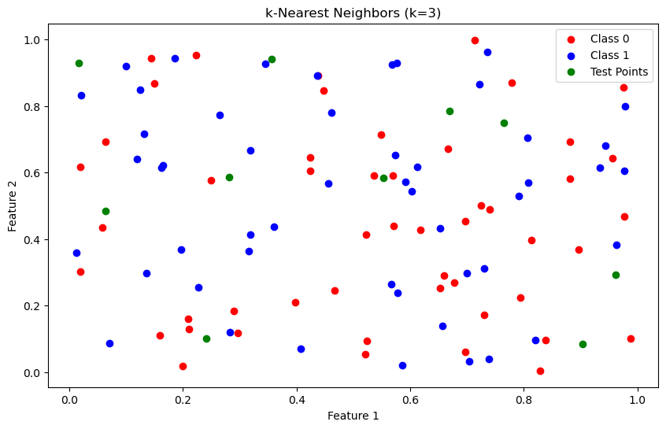

```
Predictions for test points: [1, 1, 0, 0, 0, 0, 1, 0, 1, 0]
```

```python
# Importing necessary libraries
import numpy as np
import matplotlib.pyplot as plt

# Generating sample data
np.random.seed(0)
X_train = np.random.rand(100, 2)  # 100 training samples, 2 features
y_train = np.random.randint(0, 2, 100)  # Binary classification labels (0 or 1)

X_test = np.random.rand(10, 2)  # 10 test samples, 2 features

# Implementing k-Nearest Neighbors algorithm
def euclidean_distance(x1, x2):
    return np.sqrt(np.sum((x1 - x2)**2))

def k_nearest_neighbors(X_train, y_train, X_test, k=3):
    predictions = []
    for test_point in X_test:
        # Compute distances from test_point to all points in X_train
        distances = [euclidean_distance(test_point, train_point) for train_point in X_train]

        # Get indices of k nearest neighbors
        nearest_neighbors = np.argsort(distances)[:k]

        # Predict label based on majority vote
        neighbors_labels = [y_train[i] for i in nearest_neighbors]
        prediction = max(set(neighbors_labels), key=neighbors_labels.count)
        predictions.append(prediction)

    return predictions

# Making predictions
k = 3
predictions = k_nearest_neighbors(X_train, y_train, X_test, k)

# Visualizing predictions
plt.figure(figsize=(10, 6))

plt.scatter(X_train[y_train == 0][:, 0], X_train[y_train == 0][:, 1], color='red', label='Class 0')
plt.scatter(X_train[y_train == 1][:, 0], X_train[y_train == 1][:, 1], color='blue', label='Class 1')

plt.scatter(X_test[:, 0], X_test[:, 1], color='green', label='Test Points')

plt.title(f'k-Nearest Neighbors (k={k})')
plt.legend()
plt.xlabel('Feature 1')
plt.ylabel('Feature 2')
plt.show()

print(f"Predictions for test points: {predictions}")
```

```python
import pandas as pd
from sklearn.model_selection import train_test_split
from sklearn.tree import DecisionTreeClassifier
from sklearn.metrics import accuracy_score, classification_report

# Step 1: Load the dataset into a Pandas DataFrame
df = pd.read_csv('oced.csv')


# Step 2: Data Preprocessing (if needed)
# Assuming preprocessing steps such as handling missing values and encoding categorical variables are done
# Select features and target variable
X = df[['TimeSpentOnCourse', 'NumberOfVideosWatched', 'NumberOfQuizzesTaken', 'QuizScores', 'CompletionRate']]
y = df['CourseCompletion']

# Step 3: Split data into training and testing sets
X_train, X_test, y_train, y_test = train_test_split(X, y, test_size=0.2, random_state=42)

# Step 4: Implementing Decision Tree Algorithm
# Initialize DecisionTreeClassifier
clf = DecisionTreeClassifier(random_state=42)

# Train the classifier
clf.fit(X_train, y_train)

# Step 5: Evaluate the Model
# Predict on the test data
y_pred = clf.predict(X_test)

# Evaluate accuracy
accuracy = accuracy_score(y_test, y_pred)
print(f'Accuracy: {accuracy}')

# Print classification report for more detailed evaluation
print(classification_report(y_test, y_pred))
```

```
Accuracy: 0.9166666666666666
              precision    recall  f1-score   support

           0       0.93      0.93      0.93      1068
           1       0.90      0.89      0.90       732

    accuracy                           0.92      1800
   macro avg       0.91      0.91      0.91      1800
weighted avg       0.92      0.92      0.92      1800
```

```
   UserID CourseCategory  TimeSpentOnCourse  NumberOfVideosWatched  \
0    5618         Health          29.979719                     17
1    4326           Arts          27.802640                      1
2    5849           Arts          86.820485                     14
3    4992        Science          35.038427                     17
4    3866    Programming          92.490647                     16

   NumberOfQuizzesTaken  QuizScores  CompletionRate  DeviceType  \
0                     3   50.365656       20.860773           1
1                     5   62.615970       65.632415           1
2                     2   78.458962       63.812007           1
3                    10   59.198853       95.433162           0
4                     0   98.428285       18.102478           0

   CourseCompletion
0                 0
1                 0
2                 1
3                 1
4                 0
Mean Squared Error: 0.08333333333333333
R-squared: 0.6546325290108674
```

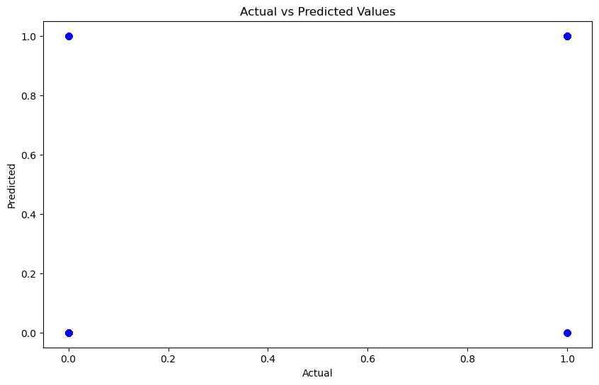

```python
import pandas as pd
from sklearn.model_selection import train_test_split
from sklearn.tree import DecisionTreeRegressor
from sklearn.metrics import mean_squared_error, r2_score
import matplotlib.pyplot as plt

# Step 1: Load the dataset into a Pandas DataFrame
df = pd.read_csv('oced.csv')

# Display the first few rows of the DataFrame to verify
print(df.head())

# Step 2: Data Preprocessing (if needed)
# Assuming preprocessing steps such as handling missing values and encoding categorical variables are done
# Select features and target variable
X = df[['TimeSpentOnCourse', 'NumberOfVideosWatched', 'NumberOfQuizzesTaken', 'QuizScores', 'CompletionRate']]
y = df['CourseCompletion']

# Step 3: Split data into training and testing sets
X_train, X_test, y_train, y_test = train_test_split(X, y, test_size=0.2, random_state=42)

# Step 4: Implementing Decision Tree Regression
# Initialize DecisionTreeRegressor
regressor = DecisionTreeRegressor(random_state=42)

# Train the regressor
regressor.fit(X_train, y_train)

# Step 5: Evaluate the Model
# Predict on the test data
y_pred = regressor.predict(X_test)

# Evaluate metrics
mse = mean_squared_error(y_test, y_pred)
r2 = r2_score(y_test, y_pred)
print(f'Mean Squared Error: {mse}')
print(f'R-squared: {r2}')

# Visualize predicted vs actual values (optional)
plt.figure(figsize=(10, 6))
plt.scatter(y_test, y_pred, color='blue')
plt.xlabel('Actual')
plt.ylabel('Predicted')
plt.title('Actual vs Predicted Values')
plt.show()
```

## Evaluation

Whether the project is successful depends on understanding Decision Tree Regression model’s strengths and weaknesses and determining how well it can predict online course completion rates. This section evaluates the model’s performance as well as reflections on lessons learnt during the project.

### Strengths

- **Interpretability:** Decision Tree Regression models offer transparency in decision-making processes, allowing stakeholders to understand how predictor variables influence course completion rates.
- **Handling Non-linearity:** The model effectively captures non-linear relationships between predictors, which is crucial in understanding complex student behaviors and engagement patterns.

### Weaknesses

- **Overfitting:** Decision Tree Regression models can easily overfit to noise in the training data, leading to poor generalization on unseen data. Techniques like pruning and setting appropriate tree depth help mitigate overfitting.
- **Dependency on Feature Selection:** The model's performance heavily relies on the selection and quality of input features. Incomplete or biased feature sets may limit the model's predictive capabilities.

### Future Directions

- **Feature Engineering:** Incorporating additional relevant features such as student demographics, course difficulty, or interaction patterns may enhance the model's predictive power.
- **Ensemble Methods:** Exploring ensemble techniques like Random Forests or Gradient Boosting can potentially improve model performance by aggregating predictions from multiple decision trees.

### Conclusion

In conclusion, while Decision Tree Regression proves effective in predicting online course completion rates, careful consideration of its strengths and weaknesses is essential. By addressing these aspects, future iterations of this project can further refine predictive models and contribute to improving student success in online learning environments.

## Conclusions

### Implications

- **Educational Interventions:** Insights from the model can inform targeted interventions to improve course design, student engagement strategies, and retention efforts.
- **Future Research:** Further exploration into advanced machine learning techniques and incorporation of additional data sources could enhance the model's predictive capabilities and provide deeper insights into online learning dynamics.

### Final Thoughts

In conclusion, while Decision Tree Regression offers valuable insights into predicting online course engagement, continuous refinement and evaluation are necessary to optimize model performance and relevance in educational contexts. By addressing these considerations, this project contributes to the ongoing efforts to enhance student success and educational outcomes in online learning environments.